# What is Naïve Bayes?

# Math is !FUN

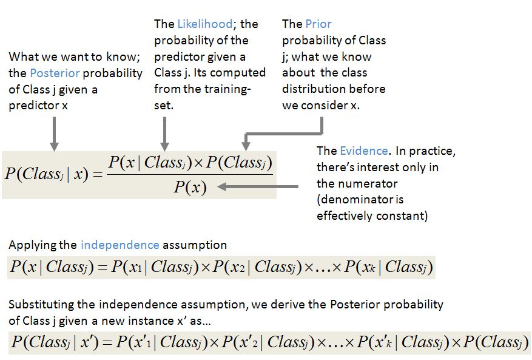

naive_bayes_maths

### What’s classification and how is it different to clustering?

It’s a machine learning model that is used to sort out different objects based on certain features.

- Classification uses **predifined classes** in which objects are assigned.
- Clustering **identifies similarities between objects** and groups the objects according to those common characteristics.

### What’s Bayes Classifier good for?

It can help us determining probability of *A* happening, given that *B* has occured.

*B* is the evidence.

*A* is the hypothesis.

#### P(A|B) = (P(B|A)*P(A)) / P(B)

# Example:

Should I go play golf or not?

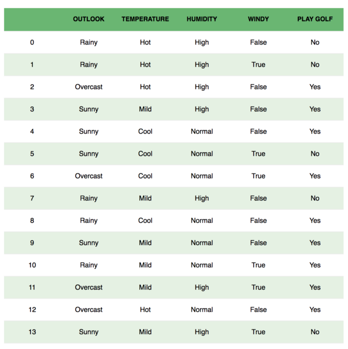

to_golf_or_not_to_golf

If I was very indicisive, I could use Bayes algorithm to help me in making the decision whether I should play golf or not.

The columns in the above dataset represent features of the day. Rows are individual entries (days).

The first entry seems unsuatable for playing golf, because it is rainy, hot and humidity is high, but it is not windy.

Two assumptions:

- Predictors are independent.
- All predictors have equal effect on the outcome. I.e. is is not more important how windy it is than how rainy it is.

## Advantages of naive Bayes:

- When assumption of feature independence holds true, the algorithm performs better than other models.
- It requires relatively little amount of data, therefore it is quick to train.
- It is (relatively) easy to implement.

## Disadvantages of naive Bayes:

- It’s main limitation is the assumption of independent predictors. It is almost impossible to achieve in real life.
- If categorical variable has a category in test data set, which was not observed in training data set, then model will assign a 0 (zero) probability and will be unable to make a prediction. This is known as “Zero Frequency”. This issue can be solved using smoothing.

Sources:

ShatterLine Blog: http://shatterline.com/blog/2013/09/12/not-so-naive-classification-with-the-naive-bayes-classifier/ (includes code for R implementation)

Towards Data Science, Naive Bayes Classifier: https://towardsdatascience.com/naive-bayes-classifier-81d512f50a7c

The Professionals Point, Advantages and Disadvantages of Naive Bayes in Machine Learning: http://theprofessionalspoint.blogspot.com/2019/03/advantages-and-disadvantages-of-naive.html

bismart, Classification Vs. Clustering - A Practical Explanation: https://blog.bismart.com/en/classification-vs.-clustering-a-practical-explanation